# Module 114

#### Contrast SVE:

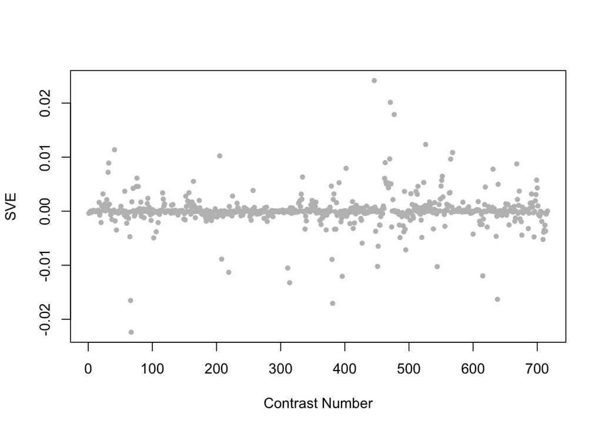

Positive SVE Contrasts:

|  | Contrast.Num | SVE | GEO.GSE | Cond.1 | Cond.2 | Mutation |
| --- | --- | --- | --- | --- | --- | --- |
| GSE27401.s2t1.vs.s3t1 | 446 | 0.02 | GSE27401 | Heat Killed C. albicans #1 | C. albicans alive #1 |  |
| GSE23528A.s1t2.vs.s0t2 | 471 | 0.02 | GSE23528 | Adult at T6 in LD, time-series experiment 3 | Adult at T6, non-entrained control time-series experiment 4 |  |
| GSE23528A.s1t2.vs.s1t1 | 477 | 0.02 | GSE23528 | Adult at T6 in LD, time-series experiment 3 | Adult at T2 in LD, time-series experiment 3 |  |
| GSE2180.s4t8.vs.s3t8 | 526 | 0.01 | GSE2180 | pp122-1 | p122-2 | pal-1(RNAi) |
| GSE9665.s12t3.vs.s0t3 | 41 | 0.01 | GSE9665 | mex-3 vab-7 230 A | mex-3 230 A | vab-7 |

Negative SVE Contrasts:

|  | Contrast.Num | SVE | GEO.GSE | Cond.1 | Cond.2 | Mutation |
| --- | --- | --- | --- | --- | --- | --- |
| GSE8659.s3t1.vs.s2t1 | 67 | -0.02 | GSE8659 | strain NL 2099 replicate 2 | strain GR1373 replicate 1 |  |
| GSE34471.s0t2.vs.s0t1 | 381 | -0.02 | GSE34471 | 20uM-Con-1 | 4uM-Con-1 |  |
| GSE8659.s3t1.vs.s1t1 | 66 | -0.02 | GSE8659 | strain NL 2099 replicate 2 | N2 replicate 1 | rrf-3 |
| GSE18132.s2t1.vs.s0t1 | 638 | -0.02 | GSE18132 | Oga starved L1, biological replicate 1 | WT Starved L1, biological rep1 | oga-1 |
| GSE41056.s2t2.vs.s2t1 | 314 | -0.01 | GSE41056 | RDE_1_inf_1 | RDE_1_1 |  |

$~$

#### Contrast SVE, Up-Regulated Genes Only:

Calculating SVE for up-regulated and down-regulated genes separately may be more informative in many cases than projecting the up- and down- gene sets together. This is due to the fact that the weight distribution of many modules is highly skewed, indicating that only one of the hemi-modules may be biologically meaningful (i.e., a set of genes are strongly correlated by only a few genes (or none) are strongly anti-correlated to that set.)

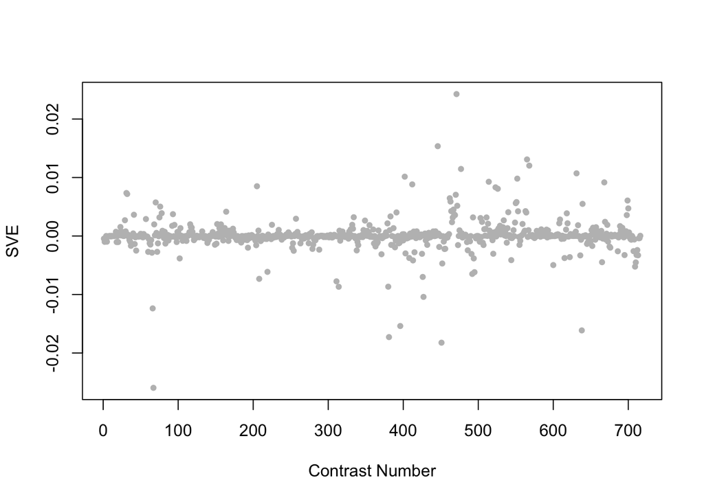

Positive SVE Contrasts:

|  | Contrast.Num | SVE | GEO.GSE | Cond.1 | Cond.2 | Mutation |
| --- | --- | --- | --- | --- | --- | --- |
| GSE23528A.s1t2.vs.s0t2 | 471 | 0.02 | GSE23528 | Adult at T6 in LD, time-series experiment 3 | Adult at T6, non-entrained control time-series experiment 4 |  |
| GSE27401.s2t1.vs.s3t1 | 446 | 0.02 | GSE27401 | Heat Killed C. albicans #1 | C. albicans alive #1 |  |
| GSE2180.s4t6.vs.s1t6 | 565 | 0.01 | GSE2180 | pp83-1 | 83-1 | pie-1(zu154);pal-1(RNAi) |
| GSE2180.s4t6.vs.s3t6 | 568 | 0.01 | GSE2180 | pp83-1 | p83-2 | pal-1(RNAi) |
| GSE23528A.s1t2.vs.s1t1 | 477 | 0.01 | GSE23528 | Adult at T6 in LD, time-series experiment 3 | Adult at T2 in LD, time-series experiment 3 |  |

Negative SVE Contrasts:

|  | Contrast.Num | SVE | GEO.GSE | Cond.1 | Cond.2 | Mutation |
| --- | --- | --- | --- | --- | --- | --- |
| GSE8659.s3t1.vs.s2t1 | 67 | -0.03 | GSE8659 | strain NL 2099 replicate 2 | strain GR1373 replicate 1 |  |
| GSE25633.s1t1.vs.s3t1 | 451 | -0.02 | GSE25633 | WT#1 | daf-12#1 | daf-12 |
| GSE34471.s0t2.vs.s0t1 | 381 | -0.02 | GSE34471 | 20uM-Con-1 | 4uM-Con-1 |  |
| GSE18132.s2t1.vs.s0t1 | 638 | -0.02 | GSE18132 | Oga starved L1, biological replicate 1 | WT Starved L1, biological rep1 | oga-1 |
| GSE32031.s1t1.vs.s0t1 | 396 | -0.02 | GSE32031 | Exerimental (nhr-23 RNAi), biological rep1 | Control, biological rep1 | nhr-23 |

$~$

#### Contrast SVE, Down-Regulated Genes Only:

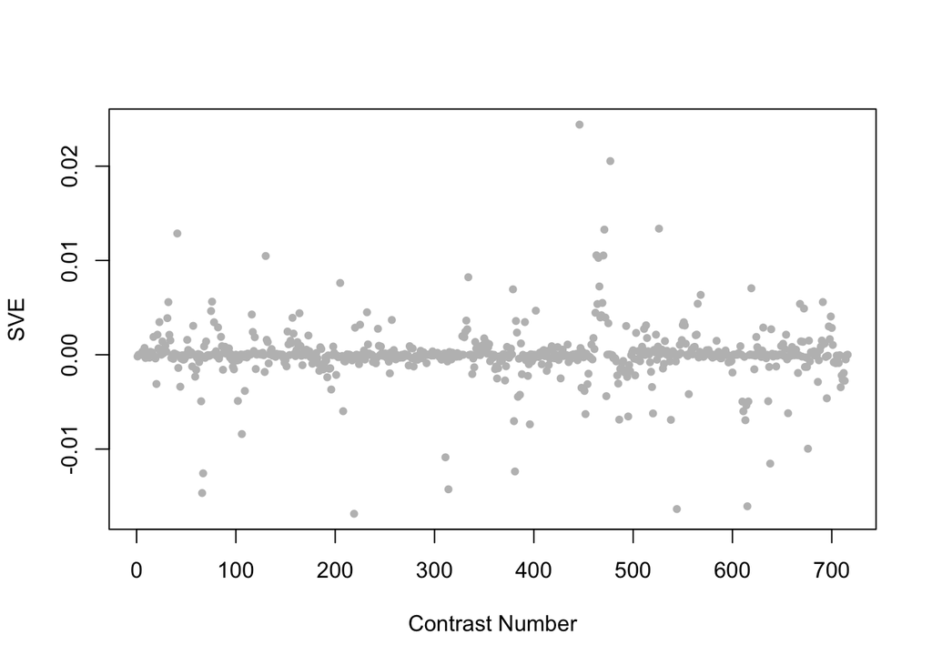

Positive SVE Contrasts:

|  | Contrast.Num | SVE | GEO.GSE | Cond.1 | Cond.2 | Mutation |
| --- | --- | --- | --- | --- | --- | --- |
| GSE27401.s2t1.vs.s3t1 | 446 | 0.02 | GSE27401 | Heat Killed C. albicans #1 | C. albicans alive #1 |  |
| GSE23528A.s1t2.vs.s1t1 | 477 | 0.02 | GSE23528 | Adult at T6 in LD, time-series experiment 3 | Adult at T2 in LD, time-series experiment 3 |  |
| GSE2180.s4t8.vs.s3t8 | 526 | 0.01 | GSE2180 | pp122-1 | p122-2 | pal-1(RNAi) |
| GSE23528A.s1t2.vs.s0t2 | 471 | 0.01 | GSE23528 | Adult at T6 in LD, time-series experiment 3 | Adult at T6, non-entrained control time-series experiment 4 |  |
| GSE9665.s12t3.vs.s0t3 | 41 | 0.01 | GSE9665 | mex-3 vab-7 230 A | mex-3 230 A | vab-7 |

Negative SVE Contrasts:

|  | Contrast.Num | SVE | GEO.GSE | Cond.1 | Cond.2 | Mutation |
| --- | --- | --- | --- | --- | --- | --- |
| GSE42592A.s1t3.vs.s0t3 | 219 | -0.02 | GSE42592 | acrylamide_low_expose-8h_rep1 | acrylamide_control_expose-8h_rep1 |  |
| GSE2180.s4t2.vs.s3t2 | 544 | -0.02 | GSE2180 | pp23-1 | p23-2 | pal-1(RNAi) |
| GSE21591.s1t1.vs.s4t1 | 615 | -0.02 | GSE21591 | N2_aFLAG_1 | aMYC_1 |  |
| GSE8659.s3t1.vs.s1t1 | 66 | -0.01 | GSE8659 | strain NL 2099 replicate 2 | N2 replicate 1 | rrf-3 |
| GSE41056.s2t2.vs.s2t1 | 314 | -0.01 | GSE41056 | RDE_1_inf_1 | RDE_1_1 |  |

$~$

$~$

#### GO Term Enrichment:

This analysis tests each hemi-module for enrichment of specific GO terms. Only gene-level annotations (e.g., as would be found on the gene’s page in Wormbase) are tested - the hierarchical structure of the GO ontology is not taken into account.

*Note: At least the top two most enriched terms from each GO domain (BP/MF/CC) are shown, even when not statistically significant.*

##### Enriched GO terms: Hemi-module A

| ID | GO.Term | GO Domain | Raw p-value | Adj p-value |
| --- | --- | --- | --- | --- |
| [GO_1902075](http://amigo.geneontology.org/amigo/term/GO:1902075) | cellular response to salt | BP | 1.32e-03 | 9.95e-01 |
| [GO_0007635](http://amigo.geneontology.org/amigo/term/GO:0007635) | chemosensory behavior | BP | 4.34e-03 | 9.95e-01 |
| [GO_0030976](http://amigo.geneontology.org/amigo/term/GO:0030976) | thiamine pyrophosphate binding | MF | 3.82e-04 | 7.80e-01 |
| [GO_0008375](http://amigo.geneontology.org/amigo/term/GO:0008375) | acetylglucosaminyltransferase activity | MF | 4.34e-03 | 9.98e-01 |
| [GO_0005832](http://amigo.geneontology.org/amigo/term/GO:0005832) | chaperonin-containing T-complex | CC | 2.23e-03 | 9.96e-01 |
| [GO_0055120](http://amigo.geneontology.org/amigo/term/GO:0055120) | striated muscle dense body | CC | 6.96e-03 | 9.96e-01 |

##### Enriched GO terms: Hemi-module B

| ID | GO.Term | GO Domain | Raw p-value | Adj p-value |
| --- | --- | --- | --- | --- |
| [GO_0045944](http://amigo.geneontology.org/amigo/term/GO:0045944) | positive regulation of transcription by RNA polymerase II | BP | 2.28e-04 | 8.32e-01 |
| [GO_0006357](http://amigo.geneontology.org/amigo/term/GO:0006357) | regulation of transcription by RNA polymerase II | BP | 9.76e-04 | 9.98e-01 |
| [GO_0001164](http://amigo.geneontology.org/amigo/term/GO:0001164) | RNA polymerase I CORE element sequence-specific DNA binding | MF | 5.49e-03 | 1.00e+00 |
| [GO_0061798](http://amigo.geneontology.org/amigo/term/GO:0061798) | GTP 3’,8’-cyclase activity | MF | 5.49e-03 | 1.00e+00 |
| [GO_0005634](http://amigo.geneontology.org/amigo/term/GO:0005634) | nucleus | CC | 9.06e-04 | 6.01e-01 |
| [GO_0043229](http://amigo.geneontology.org/amigo/term/GO:0043229) | intracellular organelle | CC | 1.30e-03 | 6.01e-01 |

$~$

$~$

#### Tissue Enrichment:

This analysis tests each hemi-module for enrichment of genes associated with anatomy terms. Negative enrichment scores indicate fewer hemi-module genes than expected by random chance were associated with the anatomy term in question.

##### Enriched tissues: Hemi-module A

No significant annotations.

##### Enriched tissues: Hemi-module B

No significant annotations.

$~$

$~$

#### HOMER promoter motif enrichment:

This analysis tests each hemi-module for enrichment of 108 known *C. elegans* transcription factor binding site motifs (see [108 CE motifs](https://katiepod.github.io//all.worm.motifs.html)) using the HOMER (Hypergeometric Optimization of Motif EnRichment) software (see [PMID:20513432](https://pubmed.ncbi.nlm.nih.gov/20513432)). HOMER was run using default parameters on sequences 1 kb upstream of the transcription start site.

##### Motif enrichment: Hemi-module A

Total target sequences = 118  
Total background sequences = 40274  
* - possible false positive

Rank

Motif

P-value

log P-pvalue

% of Targets

% of Background

STD(Bg STD)

Best Match/Details

Motif File

1 *

[figure not shown]

1e-11

-2.606e+01

7.63%

0.19%

313.5bp (280.1bp)

elt-3/MA0542.1/Jaspar(0.539)  
[More Information](https://katiepod.github.io/HomerResults/m114_a_hemi_genes.txt.out.1kb/homerResults/motif1.info.html) | [Similar Motifs Found](https://katiepod.github.io/HomerResults/m114_a_hemi_genes.txt.out.1kb/homerResults/motif1.similar.html)

[motif file (matrix)](https://katiepod.github.io/HomerResults/m114_a_hemi_genes.txt.out.1kb/homerResults/motif1.motif)

2 *

[figure not shown]

1e-11

-2.574e+01

7.63%

0.20%

214.4bp (290.1bp)

MF0011.1_HMG_class/Jaspar(0.704)  
[More Information](https://katiepod.github.io/HomerResults/m114_a_hemi_genes.txt.out.1kb/homerResults/motif2.info.html) | [Similar Motifs Found](https://katiepod.github.io/HomerResults/m114_a_hemi_genes.txt.out.1kb/homerResults/motif2.similar.html)

[motif file (matrix)](https://katiepod.github.io/HomerResults/m114_a_hemi_genes.txt.out.1kb/homerResults/motif2.motif)

3 *

[figure not shown]

1e-10

-2.414e+01

17.80%

2.88%

280.4bp (311.5bp)

POL010.1_DCE_S_III/Jaspar(0.573)  
[More Information](https://katiepod.github.io/HomerResults/m114_a_hemi_genes.txt.out.1kb/homerResults/motif3.info.html) | [Similar Motifs Found](https://katiepod.github.io/HomerResults/m114_a_hemi_genes.txt.out.1kb/homerResults/motif3.similar.html)

[motif file (matrix)](https://katiepod.github.io/HomerResults/m114_a_hemi_genes.txt.out.1kb/homerResults/motif3.motif)

4 *

[figure not shown]

1e-9

-2.290e+01

7.63%

0.29%

258.5bp (322.7bp)

MF0003.1_REL_class/Jaspar(0.599)  
[More Information](https://katiepod.github.io/HomerResults/m114_a_hemi_genes.txt.out.1kb/homerResults/motif4.info.html) | [Similar Motifs Found](https://katiepod.github.io/HomerResults/m114_a_hemi_genes.txt.out.1kb/homerResults/motif4.similar.html)

[motif file (matrix)](https://katiepod.github.io/HomerResults/m114_a_hemi_genes.txt.out.1kb/homerResults/motif4.motif)

5 *

[figure not shown]

1e-9

-2.285e+01

9.32%

0.56%

298.7bp (314.4bp)

PL0017.1_hlh-2::hlh-10/Jaspar(0.625)  
[More Information](https://katiepod.github.io/HomerResults/m114_a_hemi_genes.txt.out.1kb/homerResults/motif5.info.html) | [Similar Motifs Found](https://katiepod.github.io/HomerResults/m114_a_hemi_genes.txt.out.1kb/homerResults/motif5.similar.html)

[motif file (matrix)](https://katiepod.github.io/HomerResults/m114_a_hemi_genes.txt.out.1kb/homerResults/motif5.motif)

6 *

[figure not shown]

1e-9

-2.222e+01

12.71%

1.43%

302.0bp (327.9bp)

POL003.1_GC-box/Jaspar(0.502)  
[More Information](https://katiepod.github.io/HomerResults/m114_a_hemi_genes.txt.out.1kb/homerResults/motif6.info.html) | [Similar Motifs Found](https://katiepod.github.io/HomerResults/m114_a_hemi_genes.txt.out.1kb/homerResults/motif6.similar.html)

[motif file (matrix)](https://katiepod.github.io/HomerResults/m114_a_hemi_genes.txt.out.1kb/homerResults/motif6.motif)

7 *

[figure not shown]

1e-9

-2.215e+01

5.93%

0.12%

173.2bp (272.7bp)

mab-3/MA0262.1/Jaspar(0.613)  
[More Information](https://katiepod.github.io/HomerResults/m114_a_hemi_genes.txt.out.1kb/homerResults/motif7.info.html) | [Similar Motifs Found](https://katiepod.github.io/HomerResults/m114_a_hemi_genes.txt.out.1kb/homerResults/motif7.similar.html)

[motif file (matrix)](https://katiepod.github.io/HomerResults/m114_a_hemi_genes.txt.out.1kb/homerResults/motif7.motif)

8 *

[figure not shown]

1e-9

-2.091e+01

5.08%

0.07%

218.8bp (264.5bp)

fkh-2/MA0920.1/Jaspar(0.585)  
[More Information](https://katiepod.github.io/HomerResults/m114_a_hemi_genes.txt.out.1kb/homerResults/motif8.info.html) | [Similar Motifs Found](https://katiepod.github.io/HomerResults/m114_a_hemi_genes.txt.out.1kb/homerResults/motif8.similar.html)

[motif file (matrix)](https://katiepod.github.io/HomerResults/m114_a_hemi_genes.txt.out.1kb/homerResults/motif8.motif)

9 *

[figure not shown]

1e-9

-2.077e+01

10.17%

0.88%

286.0bp (305.2bp)

nhr-6/MA1451.1/Jaspar(0.627)  
[More Information](https://katiepod.github.io/HomerResults/m114_a_hemi_genes.txt.out.1kb/homerResults/motif9.info.html) | [Similar Motifs Found](https://katiepod.github.io/HomerResults/m114_a_hemi_genes.txt.out.1kb/homerResults/motif9.similar.html)

[motif file (matrix)](https://katiepod.github.io/HomerResults/m114_a_hemi_genes.txt.out.1kb/homerResults/motif9.motif)

10 *

[figure not shown]

1e-9

-2.076e+01

32.20%

11.19%

250.0bp (325.7bp)

PL0009.1_hlh-26/Jaspar(0.647)  
[More Information](https://katiepod.github.io/HomerResults/m114_a_hemi_genes.txt.out.1kb/homerResults/motif10.info.html) | [Similar Motifs Found](https://katiepod.github.io/HomerResults/m114_a_hemi_genes.txt.out.1kb/homerResults/motif10.similar.html)

[motif file (matrix)](https://katiepod.github.io/HomerResults/m114_a_hemi_genes.txt.out.1kb/homerResults/motif10.motif)

11 *

[figure not shown]

1e-8

-1.993e+01

4.24%

0.04%

302.1bp (284.6bp)

PL0002.1_hlh-2::hlh-3/Jaspar(0.505)  
[More Information](https://katiepod.github.io/HomerResults/m114_a_hemi_genes.txt.out.1kb/homerResults/motif11.info.html) | [Similar Motifs Found](https://katiepod.github.io/HomerResults/m114_a_hemi_genes.txt.out.1kb/homerResults/motif11.similar.html)

[motif file (matrix)](https://katiepod.github.io/HomerResults/m114_a_hemi_genes.txt.out.1kb/homerResults/motif11.motif)

12 *

[figure not shown]

1e-7

-1.838e+01

11.86%

1.62%

216.2bp (306.9bp)

LIN-39(Homeobox)/cElegans.L3-LIN39-ChIP-Seq(modEncode)/Homer(0.657)  
[More Information](https://katiepod.github.io/HomerResults/m114_a_hemi_genes.txt.out.1kb/homerResults/motif12.info.html) | [Similar Motifs Found](https://katiepod.github.io/HomerResults/m114_a_hemi_genes.txt.out.1kb/homerResults/motif12.similar.html)

[motif file (matrix)](https://katiepod.github.io/HomerResults/m114_a_hemi_genes.txt.out.1kb/homerResults/motif12.motif)

13 *

[figure not shown]

1e-7

-1.823e+01

11.86%

1.64%

319.4bp (311.7bp)

MF0005.1_Forkhead_class/Jaspar(0.667)  
[More Information](https://katiepod.github.io/HomerResults/m114_a_hemi_genes.txt.out.1kb/homerResults/motif13.info.html) | [Similar Motifs Found](https://katiepod.github.io/HomerResults/m114_a_hemi_genes.txt.out.1kb/homerResults/motif13.similar.html)

[motif file (matrix)](https://katiepod.github.io/HomerResults/m114_a_hemi_genes.txt.out.1kb/homerResults/motif13.motif)

14 *

[figure not shown]

1e-7

-1.716e+01

32.20%

12.75%

288.4bp (317.3bp)

POL008.1_DCE_S_I/Jaspar(0.587)  
[More Information](https://katiepod.github.io/HomerResults/m114_a_hemi_genes.txt.out.1kb/homerResults/motif14.info.html) | [Similar Motifs Found](https://katiepod.github.io/HomerResults/m114_a_hemi_genes.txt.out.1kb/homerResults/motif14.similar.html)

[motif file (matrix)](https://katiepod.github.io/HomerResults/m114_a_hemi_genes.txt.out.1kb/homerResults/motif14.motif)

15 *

[figure not shown]

1e-7

-1.678e+01

8.47%

0.80%

305.8bp (315.2bp)

MF0001.1_ETS_class/Jaspar(0.531)  
[More Information](https://katiepod.github.io/HomerResults/m114_a_hemi_genes.txt.out.1kb/homerResults/motif15.info.html) | [Similar Motifs Found](https://katiepod.github.io/HomerResults/m114_a_hemi_genes.txt.out.1kb/homerResults/motif15.similar.html)

[motif file (matrix)](https://katiepod.github.io/HomerResults/m114_a_hemi_genes.txt.out.1kb/homerResults/motif15.motif)

16 *

[figure not shown]

1e-7

-1.646e+01

18.64%

4.90%

295.4bp (308.0bp)

unc-62/MA0918.1/Jaspar(0.610)  
[More Information](https://katiepod.github.io/HomerResults/m114_a_hemi_genes.txt.out.1kb/homerResults/motif16.info.html) | [Similar Motifs Found](https://katiepod.github.io/HomerResults/m114_a_hemi_genes.txt.out.1kb/homerResults/motif16.similar.html)

[motif file (matrix)](https://katiepod.github.io/HomerResults/m114_a_hemi_genes.txt.out.1kb/homerResults/motif16.motif)

17 *

[figure not shown]

1e-7

-1.633e+01

19.49%

5.38%

276.1bp (333.5bp)

blmp-1/MA0537.1/Jaspar(0.671)  
[More Information](https://katiepod.github.io/HomerResults/m114_a_hemi_genes.txt.out.1kb/homerResults/motif17.info.html) | [Similar Motifs Found](https://katiepod.github.io/HomerResults/m114_a_hemi_genes.txt.out.1kb/homerResults/motif17.similar.html)

[motif file (matrix)](https://katiepod.github.io/HomerResults/m114_a_hemi_genes.txt.out.1kb/homerResults/motif17.motif)

18 *

[figure not shown]

1e-6

-1.593e+01

14.41%

3.02%

200.7bp (304.2bp)

SD0002.1_at_AC_acceptor/Jaspar(0.730)  
[More Information](https://katiepod.github.io/HomerResults/m114_a_hemi_genes.txt.out.1kb/homerResults/motif18.info.html) | [Similar Motifs Found](https://katiepod.github.io/HomerResults/m114_a_hemi_genes.txt.out.1kb/homerResults/motif18.similar.html)

[motif file (matrix)](https://katiepod.github.io/HomerResults/m114_a_hemi_genes.txt.out.1kb/homerResults/motif18.motif)

19 *

[figure not shown]

1e-6

-1.443e+01

6.78%

0.57%

274.3bp (319.6bp)

MF0002.1_bZIP_CREB/G-box-like_subclass/Jaspar(0.612)  
[More Information](https://katiepod.github.io/HomerResults/m114_a_hemi_genes.txt.out.1kb/homerResults/motif19.info.html) | [Similar Motifs Found](https://katiepod.github.io/HomerResults/m114_a_hemi_genes.txt.out.1kb/homerResults/motif19.similar.html)

[motif file (matrix)](https://katiepod.github.io/HomerResults/m114_a_hemi_genes.txt.out.1kb/homerResults/motif19.motif)

20 *

[figure not shown]

1e-6

-1.423e+01

7.63%

0.81%

244.5bp (313.6bp)

SA0002.1_at_AC_acceptor/Jaspar(0.512)  
[More Information](https://katiepod.github.io/HomerResults/m114_a_hemi_genes.txt.out.1kb/homerResults/motif20.info.html) | [Similar Motifs Found](https://katiepod.github.io/HomerResults/m114_a_hemi_genes.txt.out.1kb/homerResults/motif20.similar.html)

[motif file (matrix)](https://katiepod.github.io/HomerResults/m114_a_hemi_genes.txt.out.1kb/homerResults/motif20.motif)

21 *

[figure not shown]

1e-5

-1.272e+01

3.39%

0.07%

248.1bp (326.5bp)

skn-1/MA0547.1/Jaspar(0.601)  
[More Information](https://katiepod.github.io/HomerResults/m114_a_hemi_genes.txt.out.1kb/homerResults/motif21.info.html) | [Similar Motifs Found](https://katiepod.github.io/HomerResults/m114_a_hemi_genes.txt.out.1kb/homerResults/motif21.similar.html)

[motif file (matrix)](https://katiepod.github.io/HomerResults/m114_a_hemi_genes.txt.out.1kb/homerResults/motif21.motif)

22 *

[figure not shown]

1e-5

-1.260e+01

11.02%

2.27%

220.0bp (309.8bp)

SD0003.1_at_AC_acceptor/Jaspar(0.603)  
[More Information](https://katiepod.github.io/HomerResults/m114_a_hemi_genes.txt.out.1kb/homerResults/motif22.info.html) | [Similar Motifs Found](https://katiepod.github.io/HomerResults/m114_a_hemi_genes.txt.out.1kb/homerResults/motif22.similar.html)

[motif file (matrix)](https://katiepod.github.io/HomerResults/m114_a_hemi_genes.txt.out.1kb/homerResults/motif22.motif)

23 *

[figure not shown]

1e-5

-1.244e+01

2.54%

0.02%

314.6bp (242.4bp)

unc-86/MA0926.1/Jaspar(0.576)  
[More Information](https://katiepod.github.io/HomerResults/m114_a_hemi_genes.txt.out.1kb/homerResults/motif23.info.html) | [Similar Motifs Found](https://katiepod.github.io/HomerResults/m114_a_hemi_genes.txt.out.1kb/homerResults/motif23.similar.html)

[motif file (matrix)](https://katiepod.github.io/HomerResults/m114_a_hemi_genes.txt.out.1kb/homerResults/motif23.motif)

24 *

[figure not shown]

1e-5

-1.237e+01

3.39%

0.08%

211.2bp (263.5bp)

POL010.1_DCE_S_III/Jaspar(0.512)  
[More Information](https://katiepod.github.io/HomerResults/m114_a_hemi_genes.txt.out.1kb/homerResults/motif24.info.html) | [Similar Motifs Found](https://katiepod.github.io/HomerResults/m114_a_hemi_genes.txt.out.1kb/homerResults/motif24.similar.html)

[motif file (matrix)](https://katiepod.github.io/HomerResults/m114_a_hemi_genes.txt.out.1kb/homerResults/motif24.motif)

25 *

[figure not shown]

1e-4

-1.123e+01

2.54%

0.03%

178.4bp (303.3bp)

PL0005.1_hlh-30/Jaspar(0.593)  
[More Information](https://katiepod.github.io/HomerResults/m114_a_hemi_genes.txt.out.1kb/homerResults/motif25.info.html) | [Similar Motifs Found](https://katiepod.github.io/HomerResults/m114_a_hemi_genes.txt.out.1kb/homerResults/motif25.similar.html)

[motif file (matrix)](https://katiepod.github.io/HomerResults/m114_a_hemi_genes.txt.out.1kb/homerResults/motif25.motif)

26 *

[figure not shown]

1e-4

-1.010e+01

13.56%

4.23%

282.2bp (314.3bp)

MF0011.1_HMG_class/Jaspar(0.623)  
[More Information](https://katiepod.github.io/HomerResults/m114_a_hemi_genes.txt.out.1kb/homerResults/motif26.info.html) | [Similar Motifs Found](https://katiepod.github.io/HomerResults/m114_a_hemi_genes.txt.out.1kb/homerResults/motif26.similar.html)

[motif file (matrix)](https://katiepod.github.io/HomerResults/m114_a_hemi_genes.txt.out.1kb/homerResults/motif26.motif)

27 *

[figure not shown]

1e-4

-9.964e+00

2.54%

0.05%

209.7bp (375.1bp)

blmp-1/MA0537.1/Jaspar(0.475)  
[More Information](https://katiepod.github.io/HomerResults/m114_a_hemi_genes.txt.out.1kb/homerResults/motif27.info.html) | [Similar Motifs Found](https://katiepod.github.io/HomerResults/m114_a_hemi_genes.txt.out.1kb/homerResults/motif27.similar.html)

[motif file (matrix)](https://katiepod.github.io/HomerResults/m114_a_hemi_genes.txt.out.1kb/homerResults/motif27.motif)

28 *

[figure not shown]

1e-3

-8.487e+00

8.47%

2.09%

252.2bp (299.9bp)

blmp-1/MA0537.1/Jaspar(0.693)  
[More Information](https://katiepod.github.io/HomerResults/m114_a_hemi_genes.txt.out.1kb/homerResults/motif28.info.html) | [Similar Motifs Found](https://katiepod.github.io/HomerResults/m114_a_hemi_genes.txt.out.1kb/homerResults/motif28.similar.html)

[motif file (matrix)](https://katiepod.github.io/HomerResults/m114_a_hemi_genes.txt.out.1kb/homerResults/motif28.motif)

29 *

[figure not shown]

1e-3

-8.130e+00

9.32%

2.61%

306.5bp (329.3bp)

POL010.1_DCE_S_III/Jaspar(0.489)  
[More Information](https://katiepod.github.io/HomerResults/m114_a_hemi_genes.txt.out.1kb/homerResults/motif29.info.html) | [Similar Motifs Found](https://katiepod.github.io/HomerResults/m114_a_hemi_genes.txt.out.1kb/homerResults/motif29.similar.html)

[motif file (matrix)](https://katiepod.github.io/HomerResults/m114_a_hemi_genes.txt.out.1kb/homerResults/motif29.motif)

30 *

[figure not shown]

1e-2

-6.315e+00

5.93%

1.45%

239.8bp (339.2bp)

ceh-28/MA1445.1/Jaspar(0.750)  
[More Information](https://katiepod.github.io/HomerResults/m114_a_hemi_genes.txt.out.1kb/homerResults/motif30.info.html) | [Similar Motifs Found](https://katiepod.github.io/HomerResults/m114_a_hemi_genes.txt.out.1kb/homerResults/motif30.similar.html)

[motif file (matrix)](https://katiepod.github.io/HomerResults/m114_a_hemi_genes.txt.out.1kb/homerResults/motif30.motif)

31 *

[figure not shown]

1e-2

-5.589e+00

10.17%

4.14%

288.4bp (316.2bp)

unc-30/MA1443.1/Jaspar(0.693)  
[More Information](https://katiepod.github.io/HomerResults/m114_a_hemi_genes.txt.out.1kb/homerResults/motif31.info.html) | [Similar Motifs Found](https://katiepod.github.io/HomerResults/m114_a_hemi_genes.txt.out.1kb/homerResults/motif31.similar.html)

[motif file (matrix)](https://katiepod.github.io/HomerResults/m114_a_hemi_genes.txt.out.1kb/homerResults/motif31.motif)

##### Motif enrichment: Hemi-module B

Total target sequences = 94  
Total background sequences = 40333  
* - possible false positive

Rank

Motif

P-value

log P-pvalue

% of Targets

% of Background

STD(Bg STD)

Best Match/Details

Motif File

1 *

[figure not shown]

1e-11

-2.552e+01

8.51%

0.16%

201.5bp (305.1bp)

SD0003.1_at_AC_acceptor/Jaspar(0.624)  
[More Information](https://katiepod.github.io/HomerResults/m114_b_hemi_genes.txt.out.1kb/homerResults/motif1.info.html) | [Similar Motifs Found](https://katiepod.github.io/HomerResults/m114_b_hemi_genes.txt.out.1kb/homerResults/motif1.similar.html)

[motif file (matrix)](https://katiepod.github.io/HomerResults/m114_b_hemi_genes.txt.out.1kb/homerResults/motif1.motif)

2 *

[figure not shown]

1e-9

-2.213e+01

6.38%

0.08%

308.2bp (298.6bp)

sma-4/MA0925.1/Jaspar(0.629)  
[More Information](https://katiepod.github.io/HomerResults/m114_b_hemi_genes.txt.out.1kb/homerResults/motif2.info.html) | [Similar Motifs Found](https://katiepod.github.io/HomerResults/m114_b_hemi_genes.txt.out.1kb/homerResults/motif2.similar.html)

[motif file (matrix)](https://katiepod.github.io/HomerResults/m114_b_hemi_genes.txt.out.1kb/homerResults/motif2.motif)

3 *

[figure not shown]

1e-9

-2.113e+01

8.51%

0.30%

320.2bp (326.7bp)

DPL-1(E2F)/cElegans-Adult-ChIP-Seq(modEncode)/Homer(0.499)  
[More Information](https://katiepod.github.io/HomerResults/m114_b_hemi_genes.txt.out.1kb/homerResults/motif3.info.html) | [Similar Motifs Found](https://katiepod.github.io/HomerResults/m114_b_hemi_genes.txt.out.1kb/homerResults/motif3.similar.html)

[motif file (matrix)](https://katiepod.github.io/HomerResults/m114_b_hemi_genes.txt.out.1kb/homerResults/motif3.motif)

4 *

[figure not shown]

1e-9

-2.111e+01

31.91%

9.17%

311.1bp (305.0bp)

fkh-9/MA1440.1/Jaspar(0.559)  
[More Information](https://katiepod.github.io/HomerResults/m114_b_hemi_genes.txt.out.1kb/homerResults/motif4.info.html) | [Similar Motifs Found](https://katiepod.github.io/HomerResults/m114_b_hemi_genes.txt.out.1kb/homerResults/motif4.similar.html)

[motif file (matrix)](https://katiepod.github.io/HomerResults/m114_b_hemi_genes.txt.out.1kb/homerResults/motif4.motif)

5 *

[figure not shown]

1e-8

-2.005e+01

6.38%

0.11%

182.6bp (303.9bp)

nhr-6/MA1451.1/Jaspar(0.572)  
[More Information](https://katiepod.github.io/HomerResults/m114_b_hemi_genes.txt.out.1kb/homerResults/motif5.info.html) | [Similar Motifs Found](https://katiepod.github.io/HomerResults/m114_b_hemi_genes.txt.out.1kb/homerResults/motif5.similar.html)

[motif file (matrix)](https://katiepod.github.io/HomerResults/m114_b_hemi_genes.txt.out.1kb/homerResults/motif5.motif)

6 *

[figure not shown]

1e-8

-1.973e+01

7.45%

0.22%

174.0bp (310.6bp)

ces-2/MA0922.1/Jaspar(0.589)  
[More Information](https://katiepod.github.io/HomerResults/m114_b_hemi_genes.txt.out.1kb/homerResults/motif6.info.html) | [Similar Motifs Found](https://katiepod.github.io/HomerResults/m114_b_hemi_genes.txt.out.1kb/homerResults/motif6.similar.html)

[motif file (matrix)](https://katiepod.github.io/HomerResults/m114_b_hemi_genes.txt.out.1kb/homerResults/motif6.motif)

7 *

[figure not shown]

1e-8

-1.896e+01

8.51%

0.40%

286.4bp (318.7bp)

POL013.1_MED-1/Jaspar(0.603)  
[More Information](https://katiepod.github.io/HomerResults/m114_b_hemi_genes.txt.out.1kb/homerResults/motif7.info.html) | [Similar Motifs Found](https://katiepod.github.io/HomerResults/m114_b_hemi_genes.txt.out.1kb/homerResults/motif7.similar.html)

[motif file (matrix)](https://katiepod.github.io/HomerResults/m114_b_hemi_genes.txt.out.1kb/homerResults/motif7.motif)

8 *

[figure not shown]

1e-8

-1.866e+01

12.77%

1.37%

248.7bp (299.2bp)

ceh-38/MA1699.1/Jaspar(0.724)  
[More Information](https://katiepod.github.io/HomerResults/m114_b_hemi_genes.txt.out.1kb/homerResults/motif8.info.html) | [Similar Motifs Found](https://katiepod.github.io/HomerResults/m114_b_hemi_genes.txt.out.1kb/homerResults/motif8.similar.html)

[motif file (matrix)](https://katiepod.github.io/HomerResults/m114_b_hemi_genes.txt.out.1kb/homerResults/motif8.motif)

9 *

[figure not shown]

1e-8

-1.858e+01

11.70%

1.09%

331.5bp (330.9bp)

unc-86/MA0926.1/Jaspar(0.553)  
[More Information](https://katiepod.github.io/HomerResults/m114_b_hemi_genes.txt.out.1kb/homerResults/motif9.info.html) | [Similar Motifs Found](https://katiepod.github.io/HomerResults/m114_b_hemi_genes.txt.out.1kb/homerResults/motif9.similar.html)

[motif file (matrix)](https://katiepod.github.io/HomerResults/m114_b_hemi_genes.txt.out.1kb/homerResults/motif9.motif)

10 *

[figure not shown]

1e-7

-1.804e+01

25.53%

6.83%

276.0bp (329.7bp)

ceh-48/MA0921.1/Jaspar(0.531)  
[More Information](https://katiepod.github.io/HomerResults/m114_b_hemi_genes.txt.out.1kb/homerResults/motif10.info.html) | [Similar Motifs Found](https://katiepod.github.io/HomerResults/m114_b_hemi_genes.txt.out.1kb/homerResults/motif10.similar.html)

[motif file (matrix)](https://katiepod.github.io/HomerResults/m114_b_hemi_genes.txt.out.1kb/homerResults/motif10.motif)

11 *

[figure not shown]

1e-7

-1.798e+01

6.38%

0.16%

295.0bp (298.4bp)

SD0002.1_at_AC_acceptor/Jaspar(0.569)  
[More Information](https://katiepod.github.io/HomerResults/m114_b_hemi_genes.txt.out.1kb/homerResults/motif11.info.html) | [Similar Motifs Found](https://katiepod.github.io/HomerResults/m114_b_hemi_genes.txt.out.1kb/homerResults/motif11.similar.html)

[motif file (matrix)](https://katiepod.github.io/HomerResults/m114_b_hemi_genes.txt.out.1kb/homerResults/motif11.motif)

12 *

[figure not shown]

1e-7

-1.764e+01

20.21%

4.34%

274.7bp (313.0bp)

fkh-9/MA1440.1/Jaspar(0.643)  
[More Information](https://katiepod.github.io/HomerResults/m114_b_hemi_genes.txt.out.1kb/homerResults/motif12.info.html) | [Similar Motifs Found](https://katiepod.github.io/HomerResults/m114_b_hemi_genes.txt.out.1kb/homerResults/motif12.similar.html)

[motif file (matrix)](https://katiepod.github.io/HomerResults/m114_b_hemi_genes.txt.out.1kb/homerResults/motif12.motif)

13 *

[figure not shown]

1e-7

-1.751e+01

8.51%

0.48%

196.4bp (317.5bp)

MF0011.1_HMG_class/Jaspar(0.698)  
[More Information](https://katiepod.github.io/HomerResults/m114_b_hemi_genes.txt.out.1kb/homerResults/motif13.info.html) | [Similar Motifs Found](https://katiepod.github.io/HomerResults/m114_b_hemi_genes.txt.out.1kb/homerResults/motif13.similar.html)

[motif file (matrix)](https://katiepod.github.io/HomerResults/m114_b_hemi_genes.txt.out.1kb/homerResults/motif13.motif)

14 *

[figure not shown]

1e-7

-1.688e+01

8.51%

0.52%

286.8bp (300.1bp)

fkh-2/MA0920.1/Jaspar(0.573)  
[More Information](https://katiepod.github.io/HomerResults/m114_b_hemi_genes.txt.out.1kb/homerResults/motif14.info.html) | [Similar Motifs Found](https://katiepod.github.io/HomerResults/m114_b_hemi_genes.txt.out.1kb/homerResults/motif14.similar.html)

[motif file (matrix)](https://katiepod.github.io/HomerResults/m114_b_hemi_genes.txt.out.1kb/homerResults/motif14.motif)

15 *

[figure not shown]

1e-7

-1.685e+01

5.32%

0.09%

217.5bp (253.9bp)

pqm-1/MA1703.1/Jaspar(0.676)  
[More Information](https://katiepod.github.io/HomerResults/m114_b_hemi_genes.txt.out.1kb/homerResults/motif15.info.html) | [Similar Motifs Found](https://katiepod.github.io/HomerResults/m114_b_hemi_genes.txt.out.1kb/homerResults/motif15.similar.html)

[motif file (matrix)](https://katiepod.github.io/HomerResults/m114_b_hemi_genes.txt.out.1kb/homerResults/motif15.motif)

16 *

[figure not shown]

1e-6

-1.581e+01

10.64%

1.13%

245.6bp (327.1bp)

SD0003.1_at_AC_acceptor/Jaspar(0.562)  
[More Information](https://katiepod.github.io/HomerResults/m114_b_hemi_genes.txt.out.1kb/homerResults/motif16.info.html) | [Similar Motifs Found](https://katiepod.github.io/HomerResults/m114_b_hemi_genes.txt.out.1kb/homerResults/motif16.similar.html)

[motif file (matrix)](https://katiepod.github.io/HomerResults/m114_b_hemi_genes.txt.out.1kb/homerResults/motif16.motif)

17 *

[figure not shown]

1e-6

-1.431e+01

18.09%

4.34%

264.2bp (305.9bp)

PHA-4(Forkhead)/cElegans-Embryos-PHA4-ChIP-Seq(modEncode)/Homer(0.651)  
[More Information](https://katiepod.github.io/HomerResults/m114_b_hemi_genes.txt.out.1kb/homerResults/motif17.info.html) | [Similar Motifs Found](https://katiepod.github.io/HomerResults/m114_b_hemi_genes.txt.out.1kb/homerResults/motif17.similar.html)

[motif file (matrix)](https://katiepod.github.io/HomerResults/m114_b_hemi_genes.txt.out.1kb/homerResults/motif17.motif)

18 *

[figure not shown]

1e-6

-1.424e+01

5.32%

0.16%

300.5bp (304.9bp)

POL008.1_DCE_S_I/Jaspar(0.620)  
[More Information](https://katiepod.github.io/HomerResults/m114_b_hemi_genes.txt.out.1kb/homerResults/motif18.info.html) | [Similar Motifs Found](https://katiepod.github.io/HomerResults/m114_b_hemi_genes.txt.out.1kb/homerResults/motif18.similar.html)

[motif file (matrix)](https://katiepod.github.io/HomerResults/m114_b_hemi_genes.txt.out.1kb/homerResults/motif18.motif)

19 *

[figure not shown]

1e-5

-1.375e+01

17.02%

4.00%

232.0bp (300.5bp)

lin-14/MA0261.1/Jaspar(0.563)  
[More Information](https://katiepod.github.io/HomerResults/m114_b_hemi_genes.txt.out.1kb/homerResults/motif19.info.html) | [Similar Motifs Found](https://katiepod.github.io/HomerResults/m114_b_hemi_genes.txt.out.1kb/homerResults/motif19.similar.html)

[motif file (matrix)](https://katiepod.github.io/HomerResults/m114_b_hemi_genes.txt.out.1kb/homerResults/motif19.motif)

20 *

[figure not shown]

1e-5

-1.356e+01

6.38%

0.35%

250.8bp (312.7bp)

POL010.1_DCE_S_III/Jaspar(0.602)  
[More Information](https://katiepod.github.io/HomerResults/m114_b_hemi_genes.txt.out.1kb/homerResults/motif20.info.html) | [Similar Motifs Found](https://katiepod.github.io/HomerResults/m114_b_hemi_genes.txt.out.1kb/homerResults/motif20.similar.html)

[motif file (matrix)](https://katiepod.github.io/HomerResults/m114_b_hemi_genes.txt.out.1kb/homerResults/motif20.motif)

21 *

[figure not shown]

1e-5

-1.290e+01

9.57%

1.21%

255.9bp (305.1bp)

fkh-9/MA1440.1/Jaspar(0.645)  
[More Information](https://katiepod.github.io/HomerResults/m114_b_hemi_genes.txt.out.1kb/homerResults/motif21.info.html) | [Similar Motifs Found](https://katiepod.github.io/HomerResults/m114_b_hemi_genes.txt.out.1kb/homerResults/motif21.similar.html)

[motif file (matrix)](https://katiepod.github.io/HomerResults/m114_b_hemi_genes.txt.out.1kb/homerResults/motif21.motif)

22 *

[figure not shown]

1e-5

-1.214e+01

12.77%

2.55%

296.0bp (312.5bp)

MF0008.1_MADS_class/Jaspar(0.672)  
[More Information](https://katiepod.github.io/HomerResults/m114_b_hemi_genes.txt.out.1kb/homerResults/motif22.info.html) | [Similar Motifs Found](https://katiepod.github.io/HomerResults/m114_b_hemi_genes.txt.out.1kb/homerResults/motif22.similar.html)

[motif file (matrix)](https://katiepod.github.io/HomerResults/m114_b_hemi_genes.txt.out.1kb/homerResults/motif22.motif)

23 *

[figure not shown]

1e-5

-1.167e+01

8.51%

1.06%

276.8bp (317.8bp)

PHA-4(Forkhead)/cElegans-Embryos-PHA4-ChIP-Seq(modEncode)/Homer(0.510)  
[More Information](https://katiepod.github.io/HomerResults/m114_b_hemi_genes.txt.out.1kb/homerResults/motif23.info.html) | [Similar Motifs Found](https://katiepod.github.io/HomerResults/m114_b_hemi_genes.txt.out.1kb/homerResults/motif23.similar.html)

[motif file (matrix)](https://katiepod.github.io/HomerResults/m114_b_hemi_genes.txt.out.1kb/homerResults/motif23.motif)

24 *

[figure not shown]

1e-4

-1.151e+01

20.21%

6.55%

243.2bp (332.6bp)

POL013.1_MED-1/Jaspar(0.646)  
[More Information](https://katiepod.github.io/HomerResults/m114_b_hemi_genes.txt.out.1kb/homerResults/motif24.info.html) | [Similar Motifs Found](https://katiepod.github.io/HomerResults/m114_b_hemi_genes.txt.out.1kb/homerResults/motif24.similar.html)

[motif file (matrix)](https://katiepod.github.io/HomerResults/m114_b_hemi_genes.txt.out.1kb/homerResults/motif24.motif)

25 *

[figure not shown]

1e-4

-1.047e+01

14.89%

4.07%

283.7bp (319.2bp)

POL008.1_DCE_S_I/Jaspar(0.590)  
[More Information](https://katiepod.github.io/HomerResults/m114_b_hemi_genes.txt.out.1kb/homerResults/motif25.info.html) | [Similar Motifs Found](https://katiepod.github.io/HomerResults/m114_b_hemi_genes.txt.out.1kb/homerResults/motif25.similar.html)

[motif file (matrix)](https://katiepod.github.io/HomerResults/m114_b_hemi_genes.txt.out.1kb/homerResults/motif25.motif)

26 *

[figure not shown]

1e-4

-9.635e+00

12.77%

3.30%

276.7bp (320.2bp)

POL008.1_DCE_S_I/Jaspar(0.598)  
[More Information](https://katiepod.github.io/HomerResults/m114_b_hemi_genes.txt.out.1kb/homerResults/motif26.info.html) | [Similar Motifs Found](https://katiepod.github.io/HomerResults/m114_b_hemi_genes.txt.out.1kb/homerResults/motif26.similar.html)

[motif file (matrix)](https://katiepod.github.io/HomerResults/m114_b_hemi_genes.txt.out.1kb/homerResults/motif26.motif)

27 *

[figure not shown]

1e-4

-9.389e+00

29.79%

14.24%

243.3bp (310.8bp)

POL002.1_INR/Jaspar(0.684)  
[More Information](https://katiepod.github.io/HomerResults/m114_b_hemi_genes.txt.out.1kb/homerResults/motif27.info.html) | [Similar Motifs Found](https://katiepod.github.io/HomerResults/m114_b_hemi_genes.txt.out.1kb/homerResults/motif27.similar.html)

[motif file (matrix)](https://katiepod.github.io/HomerResults/m114_b_hemi_genes.txt.out.1kb/homerResults/motif27.motif)

28 *

[figure not shown]

1e-3

-8.888e+00

7.45%

1.18%

305.6bp (311.0bp)

ceh-38/MA1699.1/Jaspar(0.575)  
[More Information](https://katiepod.github.io/HomerResults/m114_b_hemi_genes.txt.out.1kb/homerResults/motif28.info.html) | [Similar Motifs Found](https://katiepod.github.io/HomerResults/m114_b_hemi_genes.txt.out.1kb/homerResults/motif28.similar.html)

[motif file (matrix)](https://katiepod.github.io/HomerResults/m114_b_hemi_genes.txt.out.1kb/homerResults/motif28.motif)

29 *

[figure not shown]

1e-3

-8.774e+00

4.26%

0.28%

310.7bp (280.0bp)

fkh-9/MA1440.1/Jaspar(0.675)  
[More Information](https://katiepod.github.io/HomerResults/m114_b_hemi_genes.txt.out.1kb/homerResults/motif29.info.html) | [Similar Motifs Found](https://katiepod.github.io/HomerResults/m114_b_hemi_genes.txt.out.1kb/homerResults/motif29.similar.html)

[motif file (matrix)](https://katiepod.github.io/HomerResults/m114_b_hemi_genes.txt.out.1kb/homerResults/motif29.motif)

30 *

[figure not shown]

1e-3

-8.148e+00

2.13%

0.02%

171.0bp (302.7bp)

MF0001.1_ETS_class/Jaspar(0.756)  
[More Information](https://katiepod.github.io/HomerResults/m114_b_hemi_genes.txt.out.1kb/homerResults/motif30.info.html) | [Similar Motifs Found](https://katiepod.github.io/HomerResults/m114_b_hemi_genes.txt.out.1kb/homerResults/motif30.similar.html)

[motif file (matrix)](https://katiepod.github.io/HomerResults/m114_b_hemi_genes.txt.out.1kb/homerResults/motif30.motif)

31 *

[figure not shown]

1e-2

-4.983e+00

11.70%

4.94%

228.9bp (315.2bp)

zfh-2/MA0928.1/Jaspar(0.584)  
[More Information](https://katiepod.github.io/HomerResults/m114_b_hemi_genes.txt.out.1kb/homerResults/motif31.info.html) | [Similar Motifs Found](https://katiepod.github.io/HomerResults/m114_b_hemi_genes.txt.out.1kb/homerResults/motif31.similar.html)

[motif file (matrix)](https://katiepod.github.io/HomerResults/m114_b_hemi_genes.txt.out.1kb/homerResults/motif31.motif)

32 *

[figure not shown]

1e-2

-4.679e+00

3.19%

0.45%

144.7bp (288.0bp)

lin-54/MA1450.1/Jaspar(0.572)  
[More Information](https://katiepod.github.io/HomerResults/m114_b_hemi_genes.txt.out.1kb/homerResults/motif32.info.html) | [Similar Motifs Found](https://katiepod.github.io/HomerResults/m114_b_hemi_genes.txt.out.1kb/homerResults/motif32.similar.html)

[motif file (matrix)](https://katiepod.github.io/HomerResults/m114_b_hemi_genes.txt.out.1kb/homerResults/motif32.motif)

33 *

[figure not shown]

1e-1

-3.992e+00

5.32%

1.61%

212.4bp (317.2bp)

MF0009.1_TRP(MYB)_class/Jaspar(0.678)  
[More Information](https://katiepod.github.io/HomerResults/m114_b_hemi_genes.txt.out.1kb/homerResults/motif33.info.html) | [Similar Motifs Found](https://katiepod.github.io/HomerResults/m114_b_hemi_genes.txt.out.1kb/homerResults/motif33.similar.html)

[motif file (matrix)](https://katiepod.github.io/HomerResults/m114_b_hemi_genes.txt.out.1kb/homerResults/motif33.motif)

34 *

[figure not shown]

1e-1

-3.977e+00

34.04%

24.05%

253.8bp (311.7bp)

unc-86/MA0926.1/Jaspar(0.683)  
[More Information](https://katiepod.github.io/HomerResults/m114_b_hemi_genes.txt.out.1kb/homerResults/motif34.info.html) | [Similar Motifs Found](https://katiepod.github.io/HomerResults/m114_b_hemi_genes.txt.out.1kb/homerResults/motif34.similar.html)

[motif file (matrix)](https://katiepod.github.io/HomerResults/m114_b_hemi_genes.txt.out.1kb/homerResults/motif34.motif)

$~$

$~$

#### Promoter Word Enrichment:

This analysis tests each hemi-module for enrichment of specific promoter words. The list of promoter words tested was generated by running the MobyDick algorithm (see [PMID:10944202](https://pubmed.ncbi.nlm.nih.gov/10944202)) on the full set of *C. elegans* 2 Kbp promoters.

##### Enriched promoter words: Hemi-module A

No significant words.

##### Enriched promoter words: Hemi-module B

No significant words.

$~$

$~$

#### Promoter Word Depletion:

This analysis tests each hemi-module for depletion (under-enrichment) of specific promoter words. The list of promoter words tested was generated by running the MobyDick algorithm (see [PMID:10944202](https://pubmed.ncbi.nlm.nih.gov/10944202)) on the full set of *C. elegans* 2 Kbp promoters.

##### Depleted promoter words: Hemi-module A

No significant words.

##### Depleted promoter words: Hemi-module B

No significant words.

$~$

$~$

#### 3’-UTR Word Enrichment:

This analysis tests each hemi-module for enrichment of specific 3’-UTR words. The list of words tested was generated by running the MobyDick algorithm (see [PMID:10944202](https://pubmed.ncbi.nlm.nih.gov/10944202)) on the full set of *C. elegans* 3’-UTR sequences.

##### 3’-UTR words: Hemi-module A

No significant words.

##### 3’-UTR words: Hemi-module B

No significant words.

$~$

$~$

#### Hemi-module A genes

| affy_c_elegans | ensembl_gene_id | external_gene_name | module_weight | chromosome_name | strand | start_position | end_position |
| --- | --- | --- | --- | --- | --- | --- | --- |
| 191062_s_at | WBGene00000254 | bli-4 | 6.33 | I | 1 | 6342231 | 6356678 |
| 184125_at | WBGene00007339 | C05D12.1 | 5.39 | II | -1 | 11412232 | 11415820 |
| 176412_at | WBGene00022140 | Y71G12A.4 | 5.26 | I | -1 | 1885205 | 1894905 |
| 186599_at | WBGene00013790 | Y116A8C.10 | 5.17 | IV | -1 | 16934266 | 16939111 |
| 188743_s_at | WBGene00007099 | trx-2 | 4.50 | V | 1 | 10314641 | 10315304 |
| 186381_at | WBGene00019915 | tbc-10 | 4.46 | III | 1 | 977386 | 988446 |
| 175445_at | WBGene00011962 | T23G5.2 | 4.34 | III | -1 | 9231421 | 9236322 |
| 182222_at | WBGene00002242 | kvs-1 | 4.31 | X | -1 | 7690590 | 7707086 |
| 174858_at | WBGene00022114 | Y71F9AL.9 | 4.16 | I | 1 | 2876932 | 2878523 |
| 178587_s_at | WBGene00009915 | F52A8.1 | 4.15 | I | 1 | 7317646 | 7318337 |
| 190985_at | WBGene00005594 | srj-6 | 4.09 | V | -1 | 653303 | 654502 |
| 174678_at | WBGene00014098 | ogdh-2 | 4.07 | V | 1 | 12194457 | 12205494 |
| 174020_at | WBGene00003636 | nhr-46 | 4.06 | IV | -1 | 5747376 | 5757862 |
| 182975_s_at | WBGene00004795 | sid-1 | 4.06 | V | 1 | 5119939 | 5126916 |
| 180915_at | WBGene00020266 | T05H4.3 | 4.00 | V | 1 | 6442337 | 6447556 |
| 176804_at | WBGene00018473 | cima-1 | 3.96 | IV | 1 | 7651442 | 7654295 |
| 179734_at | WBGene00044302 | F28E10.5 | 3.94 | IV | 1 | 4594132 | 4596678 |
| 180296_at | WBGene00012500 | hpo-2 | 3.94 | I | 1 | 13066924 | 13069038 |
| 192143_s_at | WBGene00010758 | vnut-1 | 3.92 | II | 1 | 14489802 | 14492901 |
| 187144_at | WBGene00006739 | ulp-4 | 3.89 | II | 1 | 8129960 | 8134742 |
| 186902_s_at | WBGene00004403 | rom-4 | 3.83 | IV | 1 | 16995777 | 17014953 |
| 190948_at | WBGene00008252 | C51E3.6 | 3.75 | V | -1 | 10164135 | 10166463 |
| 182963_at | WBGene00009085 | F23D12.1 | 3.74 | X | -1 | 14425445 | 14428152 |
| 171963_x_at | WBGene00000381 | cct-6 | 3.74 | III | -1 | 5853532 | 5855687 |
| 186526_at | WBGene00021992 | thn-6 | 3.71 | IV | 1 | 5228919 | 5230083 |
| 187652_s_at | WBGene00020604 | T20B12.7 | 3.70 | III | -1 | 7377854 | 7379045 |
| 193820_s_at | WBGene00011511 | gpcp-2 | 3.69 | II | -1 | 8067990 | 8073372 |
| 184285_at | WBGene00015437 | scrm-3 | 3.62 | V | -1 | 3355848 | 3357193 |
| 188419_at | WBGene00004235 | ptr-21 | 3.62 | I | 1 | 550696 | 556638 |
| 180145_s_at | WBGene00013103 | Y51H4A.7 | 3.61 | IV | -1 | 16535730 | 16542894 |

[output cut: 122 more lines]

#### Hemi-module B genes

| affy_c_elegans | ensembl_gene_id | external_gene_name | module_weight | chromosome_name | strand | start_position | end_position |
| --- | --- | --- | --- | --- | --- | --- | --- |
| 179247_at | WBGene00009070 | F23A7.5 | -5.17 | X | 1 | 16229463 | 16236856 |
| 175969_at | WBGene00018310 | F41G4.7 | -4.97 | X | -1 | 16833588 | 16836404 |
| 188929_at | WBGene00019085 | F59A6.3 | -4.83 | II | 1 | 5008341 | 5011179 |
| 179867_at | WBGene00013545 | Y75B8A.8 | -4.78 | III | 1 | 12160758 | 12171356 |
| 174469_at | WBGene00000110 | alh-4 | -4.68 | V | -1 | 6427212 | 6429927 |
| 176377_at | WBGene00021243 | Y22D7AL.3 | -4.59 | III | 1 | 1641463 | 1641735 |
| 185887_at | WBGene00022315 | Y81B9A.1 | -4.57 | X | 1 | 9192444 | 9194382 |
| 178546_at | WBGene00008903 | F17A2.4 | -4.55 | X | 1 | 12310812 | 12312730 |
| 188670_at | WBGene00086546 | cil-1 | -4.53 | III | -1 | 8159155 | 8161338 |
| 176487_at | WBGene00004314 | rbc-2 | -4.38 | III | -1 | 2512283 | 2528628 |
| 178109_at | WBGene00045063 | Y37A1A.4 | -4.36 | IV | 1 | 13934445 | 13964001 |
| 182847_at | WBGene00012426 | Y11D7A.1 | -4.27 | IV | -1 | 9228277 | 9231051 |
| 179719_at | WBGene00016625 | aff-1 | -4.23 | II | -1 | 6860582 | 6863752 |
| 193482_at | WBGene00001666 | gpa-4 | -4.22 | IV | 1 | 401695 | 405346 |
| 185529_at | WBGene00016349 | C33E10.8 | -4.11 | X | -1 | 17293094 | 17294828 |
| 176595_at | WBGene00022397 | Y97E10AR.2 | -3.94 | V | 1 | 7996178 | 8000233 |
| 181405_at | WBGene00022619 | ZC477.4 | -3.87 | IV | -1 | 7098542 | 7098784 |
| 186987_at | WBGene00021444 | ttc-7 | -3.85 | III | 1 | 1860429 | 1877514 |
| 187756_at | WBGene00019428 | dgk-5 | -3.85 | II | -1 | 6456522 | 6471111 |
| 175876_at | WBGene00001565 | gei-8 | -3.85 | III | -1 | 8111166 | 8126222 |
| 193985_at | WBGene00001953 | hlh-8 | -3.79 | X | 1 | 8116636 | 8120133 |
| 189611_at | WBGene00007327 | C05C9.3 | -3.77 | X | -1 | 11142971 | 11152820 |
| 192192_at | WBGene00006716 | ubc-21 | -3.75 | X | 1 | 8869625 | 8871901 |
| 186290_at | WBGene00018378 | F43C11.1 | -3.74 | II | 1 | 2357095 | 2358278 |
| 178548_at | WBGene00011041 | R05H5.7 | -3.71 | II | 1 | 10192529 | 10193451 |
| 172250_x_at | WBGene00043469 | R09H3.2 | -3.70 | X | -1 | 1664855 | 1665025 |
| 185853_at | WBGene00018094 | F36F12.3 | -3.70 | V | 1 | 2086279 | 2089819 |
| 175235_at | WBGene00008594 | clec-57 | -3.66 | V | 1 | 14469191 | 14472448 |
| 179104_at | WBGene00005764 | srw-17 | -3.65 | V | -1 | 15275443 | 15276900 |
| 176079_at | WBGene00021520 | Y41D4B.18 | -3.65 | IV | 1 | 1558053 | 1559633 |

[output cut: 71 more lines]